# Microbiome in Alkaline Geothermal Spring At Yellowstone

# The following two chunks will check the sample size distribution and visualize it.

```r
load("/local/workdir/jd2263/BIOMI6300_Project2_AmpliconAnalysis/data/preprocessed_physeq.RData")
preprocessed_physeq
```

```
## phyloseq-class experiment-level object
## otu_table()   OTU Table:         [ 538 taxa and 4 samples ]
## sample_data() Sample Data:       [ 4 samples by 9 sample variables ]
## tax_table()   Taxonomy Table:    [ 538 taxa by 9 taxonomic ranks ]
```

```r
# What are the sample size distributions?
preprocessed_physeq %>%
  sample_sums() %>%
  data.frame()
```

```
##                 .
## SRR15570324 28257
## SRR15570325 32176
## SRR15570326 24489
## SRR15570327 25951
```

```r
  #View()

# Remove sample that has fewest number of reads
# The fewest reads is 24489 and the next was 25951

physeq_2267 <- preprocessed_physeq %>%
  prune_samples(sample_sums(.) > 2000, .)
```

```r
set.seed(777)
# Scale the reads using function scale_reads from functions.R
# Intution check of number of sequeces per sample
min(sample_sums(physeq_2267))
```

```
## [1] 24489
```

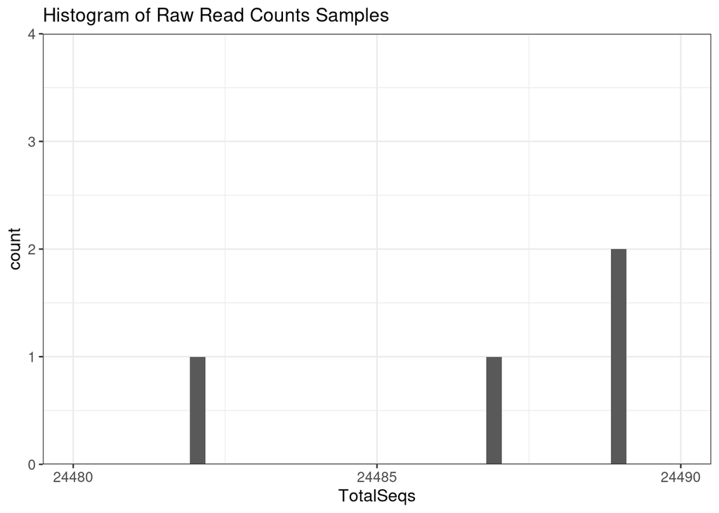

```r
scaled_physeq2267 <-
  physeq_2267 %>%
  scale_reads(round = "matround")

# Now check the sequencing depth!
scaled_seqSums_df <-
scaled_physeq2267 %>%
otu_table(.) %>%  # Take the sum of the sample abundance
colSums(.) %>%
data.frame() %>%
rownames_to_column(., var = "names") %>%
 make_MA_metadata()

 # Rename the 2nd column
 colnames(scaled_seqSums_df)[2] <- "TotalSeqs"

scaled_seqSums_df %>%
  ggplot(aes(x=TotalSeqs)) +
  ggtitle("Histogram of Raw Read Counts Samples") +
  geom_histogram(bins = 40) +
  theme(legend.position = c(0.15, 0.85)) +
  scale_y_continuous(expand = c(0, 0), limits = c(0, 4)) +
  scale_x_continuous(limits = c(24480, 24490), breaks = seq(24480,24490,5))
```

This figure simply shows the sample sequence size distribution at this step. We can tell that all 4 of the samples are within a very small range, between 24480 and 24490.

# PCoA, plot the PCoA showing the Bray-Curtis disimilarities of the data:

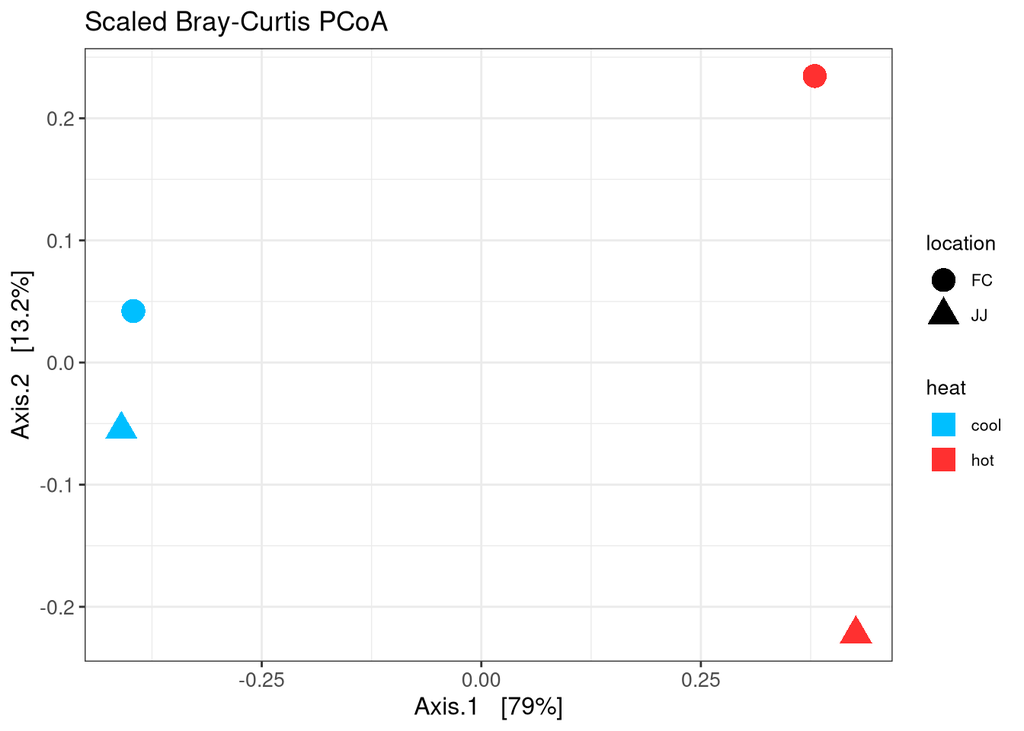

```r
# Calculate Bray-Curtis Dissimilarity
scaled_BC_pcoa <-
  ordinate(
    physeq = scaled_physeq2267,
    method = "PCoA",
    distance = "bray",
    binary = FALSE
  )


plot_ordination(
  physeq = scaled_physeq2267,
  ordination = scaled_BC_pcoa,
  color = "heat",
  shape = "location",
  title = "Scaled Bray-Curtis PCoA"
) +
  geom_point(
    size = 5,
    alpha = 6,
    aes(color = heat, shape = location),
    stroke = 0.8,
    show.legend = TRUE
  ) +
  scale_color_manual(values = heat_colors, guide = guide_legend(override.aes = list(shape = 15))) +
  scale_shape_manual(values = location_shapes)
```

# Check for differences in the communities using PERMANOVA!

```r
# Calculate bray curtis for PERMANOVA
scaled_bray <- phyloseq::distance(scaled_physeq2267, method = "bray", binary = FALSE)
# pull out metadata

metadata <- scaled_physeq2267 %>%
  sample_data() %>%
  data.frame()
# Permutational Multivariate Analysis of Variance Using Distance Matrices
# aka PERMANOVA using the adonis2 function from vegan

# using the bray curtis
# Testing if the centroids of the fractions are different?
adonis2(scaled_bray ~ location, data = metadata)
```

```
## 'nperm' >= set of all permutations: complete enumeration.
```

```
## Set of permutations < 'minperm'. Generating entire set.
```

```
## Permutation test for adonis under reduced model
## Terms added sequentially (first to last)
## Permutation: free
## Number of permutations: 23
##
## adonis2(formula = scaled_bray ~ location, data = metadata)
##          Df SumOfSqs      R2      F Pr(>F)
## location  1  0.09586 0.11636 0.2634 0.6667
## Residual  2  0.72801 0.88364
## Total     3  0.82387 1.00000
```

```r
adonis2(scaled_bray ~ heat, data = metadata)
```

```
## 'nperm' >= set of all permutations: complete enumeration.
## Set of permutations < 'minperm'. Generating entire set.
```

```
## Permutation test for adonis under reduced model
## Terms added sequentially (first to last)
## Permutation: free
## Number of permutations: 23
##
## adonis2(formula = scaled_bray ~ heat, data = metadata)
##          Df SumOfSqs      R2      F Pr(>F)
## heat      1  0.64992 0.78886 7.4722 0.3333
## Residual  2  0.17396 0.21114
## Total     3  0.82387 1.00000
```

```r
# Are they independent of each other?
adonis2(scaled_bray ~ location +heat,data = metadata)
```

```
## 'nperm' >= set of all permutations: complete enumeration.
## Set of permutations < 'minperm'. Generating entire set.
```

```
## Permutation test for adonis under reduced model
## Terms added sequentially (first to last)
## Permutation: free
## Number of permutations: 23
##
## adonis2(formula = scaled_bray ~ location + heat, data = metadata)
##          Df SumOfSqs      R2      F Pr(>F)
## location  1  0.09586 0.11636 1.2275 0.5000
## heat      1  0.64992 0.78886 8.3222 0.1667
## Residual  1  0.07809 0.09479
## Total     3  0.82387 1.00000
```

```r
# Is there an interaction between the variables?
adonis2(scaled_bray ~ location * heat, data = metadata)
```

```
## 'nperm' >= set of all permutations: complete enumeration.
## Set of permutations < 'minperm'. Generating entire set.
```

```
## No residual component
##
## adonis2(formula = scaled_bray ~ location * heat, data = metadata)
##          Df SumOfSqs R2 F Pr(>F)
## Model     3  0.82387  1
## Residual  0  0.00000  0
## Total     3  0.82387  1
```

From this PERMANOVA test, we can get conclusion that: The first test shows the results of the adonis2 test with only location as a predictor, which indicates that location does not significantly explain the variation in the data (p-value = 0.6667).

The second test shows the results of the adonis2 test with only heat as a predictor, which also indicates that heat does not significantly explain the variation in the data (p-value = 0.3333).

The third test shows the results of the adonis2 test with both location and heat as predictors, which also indicates that neither location nor heat significantly explain the variation in the data (p-values = 0.5000 and 0.1667, respectively).

The fourth test shows the results of the adonis2 test with an interaction term between location and heat as a predictor, which shows that the model explains all of the variation in the data and that there is no residual variation left (R2 = 1).

However, the results may also be due to the fact that the sample size is extremely small. If resources allow, the sample size should be much bigger and it will be easier to generate significant conclusion from it.

# Homogeniety of dispersion test: Beta dispr

Dispersion between heat(hot/cool): and between location(Fc/JJ):

```r
#Between different heats(hot/cool):
betadispr_heat <- betadisper(scaled_bray, metadata$heat)
permutest(betadispr_heat)
```

```
## 'nperm' >= set of all permutations: complete enumeration.
```

```
## Set of permutations < 'minperm'. Generating entire set.
```

```
##
## Permutation test for homogeneity of multivariate dispersions
## Permutation: free
## Number of permutations: 23
##
## Response: Distances
##           Df    Sum Sq   Mean Sq          F N.Perm  Pr(>F)
## Groups     1 0.0026008 0.0026008 4.8014e+31     23 0.04167 *
## Residuals  2 0.0000000 0.0000000
## ---
## Signif. codes:  0 '***' 0.001 '**' 0.01 '*' 0.05 '.' 0.1 ' ' 1
```

```r
#Between locations (FC, JJ):
betadispr_location<- betadisper(scaled_bray, metadata$location)

permutest(betadispr_location)
```

```
## 'nperm' >= set of all permutations: complete enumeration.
## Set of permutations < 'minperm'. Generating entire set.
```

```
##
## Permutation test for homogeneity of multivariate dispersions
## Permutation: free
## Number of permutations: 23
##
## Response: Distances
##           Df     Sum Sq    Mean Sq          F N.Perm  Pr(>F)
## Groups     1 0.00061213 0.00061213 5.0853e+31     23 0.04167 *
## Residuals  2 0.00000000 0.00000000
## ---
## Signif. codes:  0 '***' 0.001 '**' 0.01 '*' 0.05 '.' 0.1 ' ' 1
```

Then perform phylum compositional analysis by using a stack boxplot: # Compositional Analysis

```r
phylum_df <-
  scaled_physeq2267 %>%
  tax_glom(taxrank = "Phylum") %>%                     # Agglomerate/merge counts by phylum
  transform_sample_counts(function(x) {x/sum(x)}) %>%  # Transform to relative abundances
  psmelt() %>%                                         # melt into long format data frame
  dplyr::filter(Abundance > 0.01)                   # filter out phyla that are > 1% abundant


# Group the data by Phylum and Sample, and calculate the total Abundance for each group
phylum_df_grouped <- phylum_df %>%
  group_by(Phylum, Sample) %>%
  summarize(total_abundance = sum(Abundance))
```

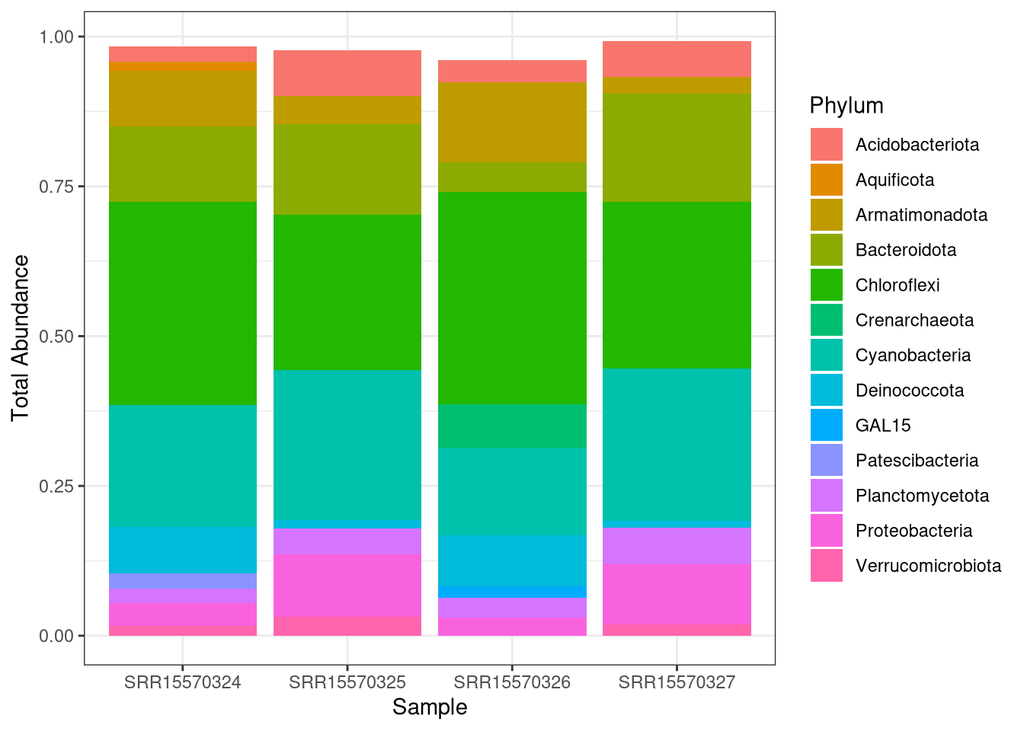

```r
# Create the stacked bar chart
ggplot(data = phylum_df_grouped, aes(x = Sample, y = total_abundance, fill = Phylum)) +
  geom_col() +
  labs(x = "Sample", y = "Total Abundance", fill = "Phylum") +
  theme_bw()
```

However, this analysis has some limitations. Firstly, the small sample size of only four samples from two locations may not be representative of the entire population of anoxygenic phototrophs across geothermal springs. Secondly, the analysis only focuses on the role of temperature and does not take into account other environmental factors that could affect the diversity and composition of the microbiome. Overall, further research and analysis with a larger dataset and a more comprehensive approach would be needed to confirm the findings presented in this document.